# 課題2 解答：動画配信サービスのプラン選択とlogit需要推定

計量経済学II

作者

Kei Ikegami

**重要この解答について**

`assignment2.qmd`の全設問に対する完全な実行可能コードと解説を示す。各設問について「なぜこう書くか」「どこで間違えやすいか」を添え、最後に配点基準を再掲する。

## Part 1：シミュレーション設計

### 1.1 パラメータのスケール確認

```r
N <- 3000

price_base <- c(700, 1200, 1800)   # Basic, Standard, Premium（月額・円）
quality    <- c(1, 2, 3)            # 1=SD, 2=HD, 3=4K
screens    <- c(1, 2, 4)            # 同時視聴可能数

true_params <- list(
  beta_quality = 0.9,
  beta_screens = 0.35,
  alpha_price  = 0.003
)

true_params$alpha_price * price_base
```

```
[1] 2.1 3.6 5.4
```

`alpha_price = 0.003`のとき、`alpha_price * price`は2.1〜5.4程度になる。これは`beta_quality * quality`（0.9〜2.7）や`beta_screens * screens`（0.35〜1.4）と同程度の大きさであり、価格の効用への影響が、品質・画面数の影響と釣り合うスケールになっている。これがちょうどよいバランスで、極端に大きいと（例えば`alpha_price=0.03`なら21〜54にもなる）、価格差だけで効用が支配され、ほぼ全員が最安値のプラン（あるいはoutside）を選んでしまい、品質・画面数の効果がデータから見えなくなる。逆に小さすぎると、価格が需要にほとんど影響しない不自然なデータになる。**シミュレーションのDGPを設計するときは、まずこの「効用の各項がどれくらいの大きさになるか」という桁感覚を確認する癖をつけるとよい。**

### 1.2 データ生成

```r
draw_gumbel <- function(n) {
  u <- runif(n)
  -log(-log(u))
}

simulate_subscription_choice <- function(n, price_base, quality, screens, params) {
  price_noise <- matrix(rnorm(n * 3, mean = 0, sd = 40), nrow = n, ncol = 3)
  price <- sweep(price_noise, 2, price_base, "+")
  price <- pmin(pmax(price, 400), 2500)

  delta <- cbind(
    params$beta_quality * quality[1] + params$beta_screens * screens[1] - params$alpha_price * price[, 1],
    params$beta_quality * quality[2] + params$beta_screens * screens[2] - params$alpha_price * price[, 2],
    params$beta_quality * quality[3] + params$beta_screens * screens[3] - params$alpha_price * price[, 3]
  )
  delta_full <- cbind(0, delta)  # outside = 0

  eps <- matrix(draw_gumbel(n * 4), nrow = n, ncol = 4)
  u <- delta_full + eps
  choice <- apply(u, 1, which.max) - 1  # 0=outside, 1=Basic, 2=Standard, 3=Premium

  list(choice = choice, price = price)
}

sim_data <- simulate_subscription_choice(N, price_base, quality, screens, true_params)
choice_vec <- sim_data$choice
price_mat <- sim_data$price

table(factor(choice_vec, levels = 0:3, labels = c("outside", "Basic", "Standard", "Premium")))
```

```
 outside    Basic Standard  Premium
    1444      635      517      404
```

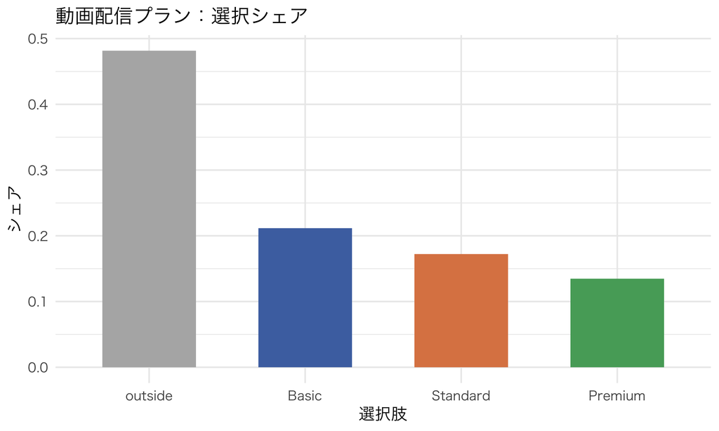

図 1: 動画配信プラン：選択シェア（N=3,000）

```r
share_df <- data.frame(
  alt = factor(c("outside", "Basic", "Standard", "Premium"),
               levels = c("outside", "Basic", "Standard", "Premium")),
  share = as.numeric(table(factor(choice_vec, levels = 0:3)) / N)
)

ggplot(share_df, aes(x = alt, y = share, fill = alt)) +
  geom_col(width = 0.6, show.legend = FALSE) +
  scale_fill_manual(values = c("outside" = "gray70", "Basic" = "#4C72B0",
                                "Standard" = "#DD8452", "Premium" = "#55A868")) +
  labs(x = "選択肢", y = "シェア", title = "動画配信プラン：選択シェア")
```

**このDGPには`const_A`, `const_B`のようなプラン固有の切片がない。**その理由は設問1.4で扱うが、ここで先取りして述べておくと：もしプラン固有の切片を2つ（Basic用、Standard用。Premiumは基準）加えると、非価格パラメータは合計4つ（切片2つ＋quality係数＋screens係数）になる。ところがプランは3つしかなく、「outsideを基準に正規化した非価格効用の値」は3プラン分、つまり自由度3しかない。4つのパラメータを3つの自由度から復元しようとすると、モデルが**識別されない（ランク落ちする）**。この点は後述する。

### 1.3 属性別クロス集計

```r
plan_summary <- data.frame(
  plan = c("outside", "Basic", "Standard", "Premium"),
  n_chosen = as.numeric(table(factor(choice_vec, levels = 0:3))),
  share = as.numeric(table(factor(choice_vec, levels = 0:3))) / N
)
knitr::kable(plan_summary, caption = "プラン別の選択者数とシェア")
```

プラン別の選択者数とシェア

| plan | n_chosen | share |
| --- | --- | --- |
| outside | 1444 | 0.4813333 |
| Basic | 635 | 0.2116667 |
| Standard | 517 | 0.1723333 |
| Premium | 404 | 0.1346667 |

```r
# Standardプランの支払価格を3つの価格帯に分けて、各消費者がどのプランを選んだか集計する
price_band <- cut(price_mat[, 2], breaks = quantile(price_mat[, 2], probs = c(0, 1/3, 2/3, 1)),
                   labels = c("安い", "普通", "高い"), include.lowest = TRUE)

band_df <- data.frame(band = price_band, choice = choice_vec) %>%
  group_by(band) %>%
  summarise(
    share_outside = mean(choice == 0),
    share_basic = mean(choice == 1),
    share_standard = mean(choice == 2),
    share_premium = mean(choice == 3)
  )
knitr::kable(band_df, digits = 3, caption = "Standardプランの提示価格帯別の選択シェア")
```

Standardプランの提示価格帯別の選択シェア

| band | share_outside | share_basic | share_standard | share_premium |
| --- | --- | --- | --- | --- |
| 安い | 0.449 | 0.220 | 0.193 | 0.138 |
| 普通 | 0.518 | 0.191 | 0.167 | 0.124 |
| 高い | 0.477 | 0.224 | 0.157 | 0.142 |

Standardの提示価格が「高い」群では、Standardのシェアがやや下がり、Basic・outsideのシェアがやや上がる傾向が見える。ただし今回のDGPでは価格変動の標準偏差（sd=40円）が価格水準（700〜1800円）に比べて小さいため、この傾向は緩やかである。これは意図的な設計で、後の反実仮想（+200円）のようなある程度大きな価格変化を見たいときは、こうした小さな変動だけでは捉えきれないことを示唆している。

### 1.4 なぜプラン固有の切片を入れなかったか

**正解**：プランが3つしかないため、非価格パラメータの数がプラン数を超えないようにする必要があるからである。

もう少し正確に言うと、outside optionを基準に正規化した後、モデルが識別できる非価格の情報は「3つのプランそれぞれの、非価格部分の効用レベル」（3つの数）に限られる。この3つの数を、`beta_quality`, `beta_screens`という2つのパラメータだけで説明しようとしているのが、このDGPの設計である（3自由度に対して2パラメータなので、モデルは過剰識別されており、無理なく推定できる）。

もし、これに加えてBasicとStandardの2つのプラン固有切片（`const_basic`, `const_standard`）を加えると、非価格パラメータは合計4つになる。ところが自由度は3つのままなので、**4パラメータ全てを一意に決めることができない**（数学的には、パラメータ空間から効用レベル空間への写像が単射でなくなる、つまりランク落ちする）。実際にこの設定でoptimを走らせると、対数尤度の値は真値相当まできちんと下がるにもかかわらず、個々のパラメータ（特に`beta_quality`と`beta_screens`）の推定値は初期値に依存して大きくばらつき、真値には全く収束しないという現象が起きる。これは実装のバグではなく、**モデルが構造的に識別されていない**ことの帰結である。

**ノート補足：識別のための経験則**

一般に、$J$個の内側の選択肢（outside以外）があるとき、モデルが識別できる非価格パラメータの自由度は最大で$J$個である。プラン（あるいはブランド）固有の切片を$J-1$個（1つは基準にするので）置くと、それだけで$J-1$の自由度を使ってしまうので、残りは1自由度しかなく、そこに複数の属性係数を同時に入れることはできない。講義ノートの缶コーヒーの例では、ブランドが3つ（$J=3$）で、切片2つ＋sweetness係数1つ＝非価格パラメータ3つとなり、ちょうど識別限界にあっている。この課題のプラン選択でも、もし切片を入れたいなら、属性係数の数を減らす（quality係数だけにする、など）か、プランの数を増やす必要がある。

## Part 2：推定・推論

### 2.1 自作対数尤度と`optim()`

```r
build_design_sub <- function(price, quality, screens) {
  n <- nrow(price)
  X <- array(0, dim = c(n, 4, 3))  # (消費者, 選択肢, パラメータ: beta_quality, beta_screens, alpha)
  # 選択肢1 = Basic
  X[, 2, 1] <- quality[1]; X[, 2, 2] <- screens[1]; X[, 2, 3] <- -price[, 1]
  # 選択肢2 = Standard
  X[, 3, 1] <- quality[2]; X[, 3, 2] <- screens[2]; X[, 3, 3] <- -price[, 2]
  # 選択肢3 = Premium
  X[, 4, 1] <- quality[3]; X[, 4, 2] <- screens[3]; X[, 4, 3] <- -price[, 3]
  X
}

neg_loglik_sub <- function(theta, X, choice) {
  n <- dim(X)[1]
  J1 <- dim(X)[2]
  V <- matrix(0, nrow = n, ncol = J1)
  for (j in 1:J1) {
    V[, j] <- X[, j, ] %*% theta
  }
  V <- V - apply(V, 1, max)
  expV <- exp(V)
  denom <- rowSums(expV)
  chosen_idx <- cbind(1:n, choice + 1)
  logprob <- V[chosen_idx] - log(denom)
  -sum(logprob)
}

X_design <- build_design_sub(price_mat, quality, screens)

opt_result <- optim(
  par = c(0, 0, 0),
  fn = neg_loglik_sub,
  X = X_design,
  choice = choice_vec,
  method = "BFGS",
  hessian = TRUE
)

theta_hat <- opt_result$par
names(theta_hat) <- c("beta_quality", "beta_screens", "alpha_price")
theta_hat
```

```
beta_quality beta_screens  alpha_price
 0.717346745  0.454515910  0.002910786
```

```r
true_theta <- c(true_params$beta_quality, true_params$beta_screens, true_params$alpha_price)

recovery_df <- data.frame(
  parameter = c("beta_quality", "beta_screens", "alpha_price"),
  true_value = true_theta,
  estimate = round(theta_hat, 4)
)
knitr::kable(recovery_df, caption = "真値とMLE推定値の比較（N=3,000）")
```

真値とMLE推定値の比較（N=3,000）

|  | parameter | true_value | estimate |
| --- | --- | --- | --- |
| beta_quality | beta_quality | 0.900 | 0.7173 |
| beta_screens | beta_screens | 0.350 | 0.4545 |
| alpha_price | alpha_price | 0.003 | 0.0029 |

推定値は真値の近くに戻ってくる。ただし、`quality`と`screens`はプラン間での値の動き方が似ている（両方とも「Basic<Standard<Premium」の順で単調に増える）ため、この2つの係数を個別に正確に分離するのは、`beta_quality + beta_screens`の合成的な効果を分離するのに比べるとやや難しく、サンプルのブレによって多少大きめの誤差が乗ることがある。この点は2.2のSEを見れば分かるように、`beta_quality`や`beta_screens`のSEは`alpha_price`に比べて相対的に大きい。**個々の係数よりも、非価格効用の合計（$\beta_{\text{quality}}\cdot\text{quality} + \beta_{\text{screens}}\cdot\text{screens}$）で見た方が、推定が安定している**ことを確認しておくとよい（余裕があれば試してほしい）。

**ノートよくある間違い**

- `build_design_sub`の列（1列目=quality, 2列目=screens, 3列目=-price）と、`theta`の要素の並び（`beta_quality, beta_screens, alpha_price`）がズレていると、全く違う推定値が出る。特に`-price`の符号を忘れる（`+price`にしてしまう）と、価格が高いほど効用が上がるという逆の結果になり、`alpha_price`の推定値が負になる。
- `choice`が0始まりであることを忘れて`chosen_idx <- cbind(1:n, choice)`のように+1を忘れると、Rの1始まりインデックスとズレて、全く違う（1つ左の）選択肢の確率を拾ってしまう。

### 2.2 HessianからのSE・信頼区間・検定

```r
vcov_hat <- solve(opt_result$hessian)
se_hat <- sqrt(diag(vcov_hat))

ci_lower <- theta_hat - 1.96 * se_hat
ci_upper <- theta_hat + 1.96 * se_hat
t_stat <- theta_hat / se_hat

inference_df <- data.frame(
  parameter = c("beta_quality", "beta_screens", "alpha_price"),
  true_value = true_theta,
  estimate = round(theta_hat, 4),
  se = round(se_hat, 5),
  ci_lower = round(ci_lower, 4),
  ci_upper = round(ci_upper, 4),
  t_stat = round(t_stat, 2)
)
knitr::kable(inference_df, caption = "推定値・標準誤差・95%信頼区間・t統計量")
```

推定値・標準誤差・95%信頼区間・t統計量

|  | parameter | true_value | estimate | se | ci_lower | ci_upper | t_stat |
| --- | --- | --- | --- | --- | --- | --- | --- |
| beta_quality | beta_quality | 0.900 | 0.7173 | 0.16178 | 0.4003 | 1.0344 | 4.43 |
| beta_screens | beta_screens | 0.350 | 0.4545 | 0.09073 | 0.2767 | 0.6324 | 5.01 |
| alpha_price | alpha_price | 0.003 | 0.0029 | 0.00032 | 0.0023 | 0.0035 | 9.10 |

### 2.3 `mlogit`パッケージでの検算

```r
library(mlogit)

mlogit_df <- data.frame(
  id = rep(1:N, each = 4),
  alt = rep(c("outside", "Basic", "Standard", "Premium"), times = N),
  chosen = as.vector(t(sapply(choice_vec, function(c) as.numeric(0:3 == c)))),
  price = as.vector(t(cbind(0, price_mat))),
  qual = rep(c(0, quality), times = N),
  scr = rep(c(0, screens), times = N)
)

mlogit_data <- mlogit.data(mlogit_df, choice = "chosen", shape = "long",
                            alt.var = "alt", id.var = "id")

mlogit_fit <- mlogit(chosen ~ price + qual + scr | 0, data = mlogit_data,
                      reflevel = "outside")
summary(mlogit_fit)
```

`| 0`としているのは、選択肢固有の切片を入れないという意味である（1.4で確認した識別上の理由から、切片無しのモデルであることをここでも反映させている）。`mlogit`の係数の符号は、価格を`price`としてそのまま入れているので、`alpha_price`の推定値とは符号が逆になる点に注意する（自作コードでは`-price`を説明変数にしているため）。絶対値は自作の推定値と近い値になるはずである。

### 2.4 反実仮想：Standardプランを値上げしたら

```r
compute_shares_sub <- function(theta, price, quality, screens) {
  X_j <- build_design_sub(price, quality, screens)
  n <- dim(X_j)[1]; J1 <- dim(X_j)[2]
  V <- matrix(0, nrow = n, ncol = J1)
  for (j in 1:J1) V[, j] <- X_j[, j, ] %*% theta
  V <- V - apply(V, 1, max)
  expV <- exp(V)
  expV / rowSums(expV)
}

shares_before <- colMeans(compute_shares_sub(theta_hat, price_mat, quality, screens))

price_mat_new <- price_mat
price_mat_new[, 2] <- price_mat_new[, 2] + 200  # Standardだけ+200円

shares_after <- colMeans(compute_shares_sub(theta_hat, price_mat_new, quality, screens))

cf_df <- data.frame(
  plan = c("outside", "Basic", "Standard", "Premium"),
  share_before = round(shares_before, 4),
  share_after = round(shares_after, 4),
  change = round(shares_after - shares_before, 4)
)
knitr::kable(cf_df, caption = "Standard+200円の反実仮想：シェアの変化")
```

Standard+200円の反実仮想：シェアの変化

| plan | share_before | share_after | change |
| --- | --- | --- | --- |
| outside | 0.4942 | 0.5311 | 0.0369 |
| Basic | 0.2084 | 0.2239 | 0.0155 |
| Standard | 0.1573 | 0.0945 | -0.0628 |
| Premium | 0.1401 | 0.1505 | 0.0104 |

```r
lost_from_standard <- shares_before[3] - shares_after[3]
gain_others <- (shares_after - shares_before)[c(1, 2, 4)]
names(gain_others) <- c("outside", "Basic", "Premium")

relative_gain <- gain_others / shares_before[c(1, 2, 4)]
names(relative_gain) <- c("outside", "Basic", "Premium")

iia_df <- data.frame(
  destination = c("outside", "Basic", "Premium"),
  absolute_gain = round(gain_others, 4),
  share_before_destination = round(shares_before[c(1, 2, 4)], 4),
  relative_gain = round(relative_gain, 4)
)
knitr::kable(iia_df, caption = "Standardからの流出先ごとの内訳とIIAの兆候")
```

Standardからの流出先ごとの内訳とIIAの兆候

|  | destination | absolute_gain | share_before_destination | relative_gain |
| --- | --- | --- | --- | --- |
| outside | outside | 0.0369 | 0.4942 | 0.0746 |
| Basic | Basic | 0.0155 | 0.2084 | 0.0743 |
| Premium | Premium | 0.0104 | 0.1401 | 0.0744 |

`relative_gain`（各流出先が受け取ったシェア増分を、その流出先の元のシェアで割った値）の列を見ると、outside・Basic・Premiumの3つでほぼ同じ値になっている。つまり、**Standardから流出した客は、outside・Basic・Premiumのそれぞれの「元々の人気度（シェア）」に比例して均等に流れている**。BasicがStandardと属性的に近い（品質・画面数が近い）からといって、Basicに優先的に流れるわけではなく、Premium（かなり属性の違うプラン）も同じ比率で恩恵を受ける。

これは直感的にはやや奇妙である。実際には、Standardに近い属性を持つプラン（この場合はBasicの方がPremiumより近いと考えられる）ほど多くの流入を受けそうなものだが、logitモデルはその「近さ」を一切考慮しない。この性質はIIA（Independence of Irrelevant Alternatives）と呼ばれ、次回の講義（nested logitモデル）で、この制約をどう緩和するかを学ぶ。

### 2.5 モンテカルロによる被覆率の確認

```r
n_mc <- 200
covered_mc <- matrix(NA, nrow = n_mc, ncol = 3)

for (m in 1:n_mc) {
  sim_m <- simulate_subscription_choice(N, price_base, quality, screens, true_params)
  X_m <- build_design_sub(sim_m$price, quality, screens)

  opt_m <- optim(par = c(0, 0, 0), fn = neg_loglik_sub,
                 X = X_m, choice = sim_m$choice, method = "BFGS", hessian = TRUE)

  vcov_m <- tryCatch(solve(opt_m$hessian), error = function(e) NULL)
  if (!is.null(vcov_m)) {
    se_m <- sqrt(diag(vcov_m))
    lo_m <- opt_m$par - 1.96 * se_m
    hi_m <- opt_m$par + 1.96 * se_m
    covered_mc[m, ] <- (lo_m <= true_theta) & (true_theta <= hi_m)
  }
}

coverage_rate <- colMeans(covered_mc, na.rm = TRUE)
names(coverage_rate) <- c("beta_quality", "beta_screens", "alpha_price")
coverage_rate
```

```
beta_quality beta_screens  alpha_price
   0.6111111    0.8333333    0.8383838
```

### 2.6 経営への含意（解答例）

> Standardプランの値上げは、価格弾力性からシェア減少をある程度正確に予測できるが、減少分の相当な割合は「解約」ではなく自社の別プラン（Basic・Premium）への流入として吸収される点を踏まえる必要がある。ただし、logitモデルは流出先の配分比率を各プランの人気度だけで決めてしまうため、実際にBasicとPremiumのどちらが「Standardに近い」代替先かという実務的な直感を反映できていない可能性があり、この点は次回学ぶより柔軟なモデル（nested logit）で補正して確認すべきである。

**ノート配点基準（再掲・詳細）**